# Donkey

Team

5/14/2020

## Introduction

Veterinarians give medications to diagnose, treat, or prevent illness. depending on the specific ailment, drugs come in different forms and are administered take them in many different ways. With the dangers of farmers attempting to prescribe dosages themselves, they depend on healthcare providers to understand the right way to administer them and reduce the risks. Depending on the size and temperament of an animal, say a dog versus a donkey, it may be easier or harder to weigh animals directly. Over the years methods have been developed to weigh a donkey indirectly using simple measuring devices and use these measurements to approximate the weight of the donkey.

Estimating donkey weights data is an incredibly important task in the lives of these farmers who depend on donkeys to deliver items ranging from building materials to textiles. A donkey weight is not relatively complicated and but it conveys information about all aspects of drug administration, so dosages must be only evaluated by a trained technician. For the same reasons, there is interest in generating algorithms or models to characterize weights to potentially aid in this process.

Each measurement of a donkey consists of the following: the BCS, Age,Sex,Length,Girth,Height,Weight, and WeightAlt. The measuremnts these individual components are clinically important, as these characteristics can help a veterinarian find abnormalities in the health of a donkey, allowing for crucial diagnoses. Previous studies within statistics and machine learning that seek to classify donkey weight for varying sizes have applied least-squares regression methods (Milner)

```r
library(dplyr)
```

```r
library(ggplot2)
library(olsrr)
library(lmtest)
library(numbers)
```

# Load in data

```r
load('donkeys.rda')
head(donkeys)
```

```
##   BCS Age      Sex Length Girth Height Weight WeightAlt
## 1   3  <2 stallion     78    90     90     77        NA
## 2 2.5  <2 stallion     91    97     94    100        NA
## 3 1.5  <2 stallion     74    93     95     74        NA
## 4   3  <2   female     87   109     96    116        NA
## 5 2.5  <2   female     79    98     91     91        NA
## 6 1.5  <2   female     86   102     98    105        NA
```

```r
train = data.frame(read.table("train2.csv", sep=",", header=TRUE))
test = data.frame(read.table("test2.csv", sep=",", header=TRUE))

train$BCS <- as.factor(train$BCS)
train$Age <- as.factor(train$Age)
train$Sex <- as.factor(train$Sex)
#train$Legs <- train$Height - train$Girth/pi

test$BCS <- as.factor(test$BCS)
test$Age <- as.factor(test$Age)
test$Sex <- as.factor(test$Sex)
#test$Legs <- test$Height - test$Girth/pi
```

```r
# read in data
donkeys = read.csv("mysavefile.csv")

# drop BCS = 4.5 and BCS = 1
donkeys <- subset(donkeys, BCS!=4.5 & BCS!=1)

# drop baby donkey
donkeys <- subset(donkeys, Weight != 27)
donkeys <- donkeys[order(donkeys$Weight),]

# train-test split
train <- NULL
test <- NULL
for(i in 1:nrow(donkeys)){
  if (mod(i,5) == 4){
    test <- rbind(test, donkeys[i,])
  }
  else{
    train <- rbind(train, donkeys[i,])
  }
}

train$BCS <- as.factor(train$BCS)
train$Age <- as.factor(train$Age)
train$Sex <- as.factor(train$Sex)
#train$Legs <- train$Height - train$Girth/pi

test$BCS <- as.factor(test$BCS)
test$Age <- as.factor(test$Age)
test$Sex <- as.factor(test$Sex)
```

```r
# mean weights for different donkey sexes
mean(subset(donkeys, Sex == 'stallion')$Weight)
```

```
## [1] 148.4178
```

```r
mean(subset(donkeys, Sex == 'female')$Weight)
```

```
## [1] 151.1486
```

```r
mean(subset(donkeys, Sex == 'gelding')$Weight)
```

```
## [1] 166.1646
```

# EDA

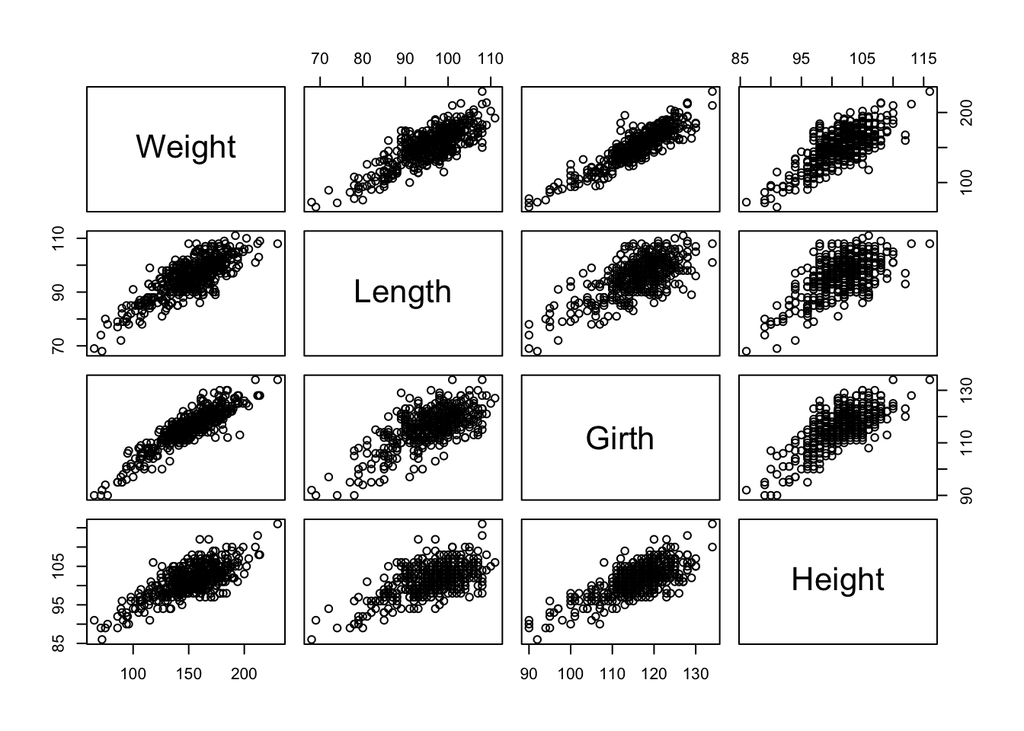

```r
# pairs(Weight~BCS + Age + Sex + Length + Girth + Height, data = donkeys)
pairs(Weight~Length + Girth + Height, data = train)
```

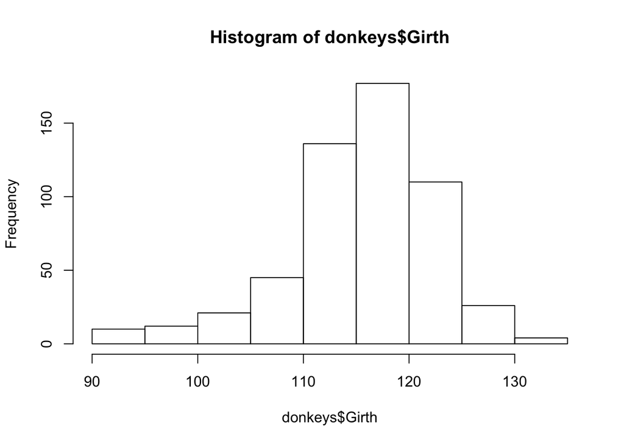

```r
# Distributions of Quantitative variables
hist(donkeys$Girth)
```

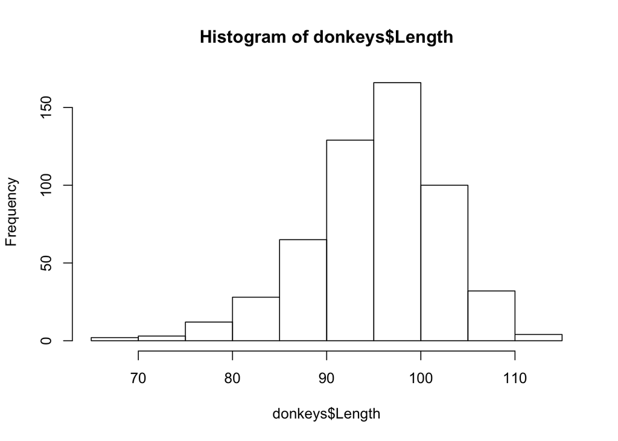

```r
hist(donkeys$Length)
```

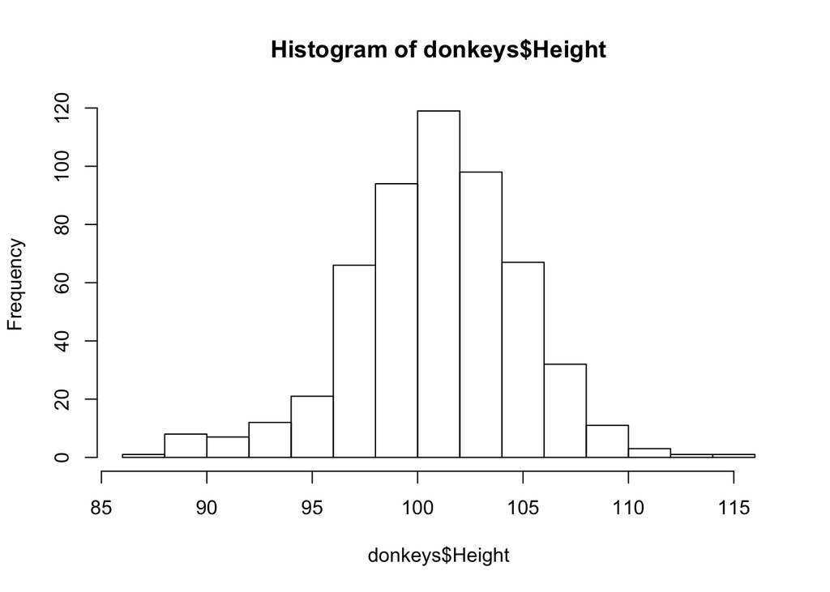

```r
hist(donkeys$Height)
```

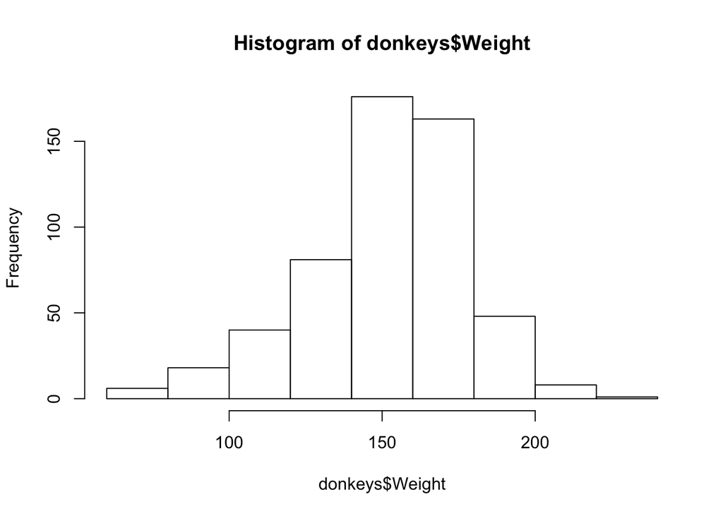

```r
hist(donkeys$Weight)
```

# Reproducing results in paper

```r
f = -107 + 19.91*log(test$Girth)
g = 7.712*log(test$Length)
raw_weight = (((f+g)/2) + 1)^2
```

```r
age_adjustment <- function(num){
  list = c(-8,0,0,0,-4,0)
  return(list[num])
}
bcs_adjustment <- function(num){
  list = c(-6,-5,0,6,14)
  return(list[num])
}
age = sapply(as.numeric(test$Age),age_adjustment)
bcs = sapply(as.numeric(test$BCS),bcs_adjustment)
```

```r
predictions = raw_weight + age + bcs
residuals = predictions - test$Weight
MSE = mean(residuals^2)
print(MSE)
```

```
## [1] NA
```

```r
relative_error = predictions/test$Weight
print(mean((relative_error-1)^2))
```

```
## [1] NA
```

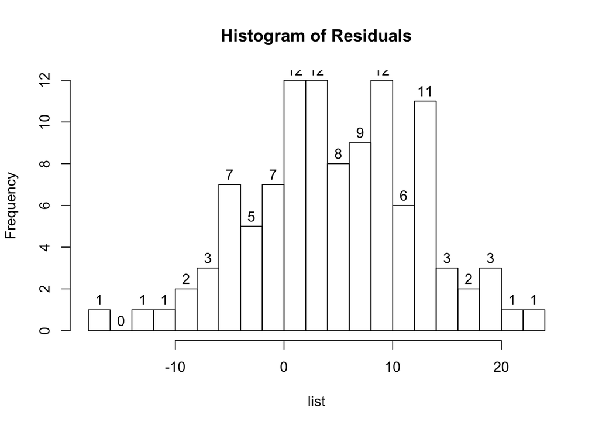

```r
plot_histogram <- function(list, title, subdivide){
  if (subdivide){
    h <- hist(list, main=title, breaks = 16)
  }
  else{
    h <- hist(list, main=title)
  }
  text(h$mids,h$counts,labels=h$counts, adj=c(0.5, -0.5))
}
plot_histogram(residuals, "Histogram of Residuals", TRUE)
```

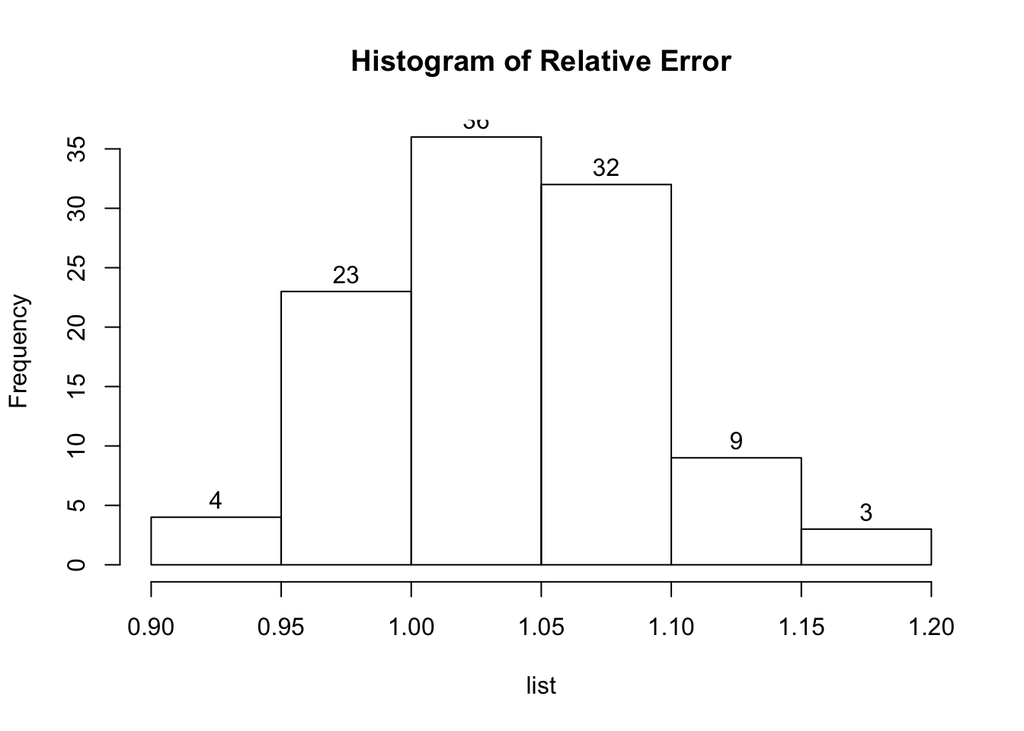

```r
plot_histogram(relative_error, "Histogram of Relative Error", FALSE)
```

# Issues/Notes with model

# Proposed model

$$Weight = \beta_0e^{\beta_1I_{[BCS=1.5]}}e^{\beta_2I_{[BCS=2]}}e^{\beta_3I_{[BCS=2.5]}}e^{\beta_4I_{[BCS=3]}}e^{\beta_5I_{[BCS=3.5]}}e^{\beta_6I_{[BCS=4]}}e^{\beta_7I_{[Age<2]}}e^{\beta_8I_{[Age \in [2,5]]}}e^{\beta_9I_{[Age>5]}}e^{\beta_{10}I_{[Sex=female]}}e^{\beta_{11}I_{[Sex=stallion]}}e^{\beta_{12}I_{[Sex=gelding]}}Length^{\beta_{13}}Girth^{\beta_{14}}Height^{\beta_{15}}$$

## Interpretation

- Toy example, donkey $i$ with $BCS = 3, \ Age = 3, \ Sex = female, \ Weight_i = \beta_0e^{\beta_4}e^{\beta_8}e^{\beta_{10}}Length^{\beta_13}Girth^{\beta_{14}}Height^{\beta_{15}}$
- In other words, the BCS, Age and Sex category of the donkey give proportionate adjustments. These adjustments are determined by which categories the donkey falls into.
- If we assume the donkey to be cylindrical and of uniform density, we expect $\beta_{13} \sim 1, \beta_{14} \sim 2$, unlike values that were given in original model.
- $Height^{\beta_{15}}$ is a proxy for frame of body, and therefore, the proportion of volume that consists of bones. This gives a proportionate adjustment to the weight.
- It is worthwhile to note that as Length, Girth, or Height tends to 0, our model also predicts that weight tends to 0, unlike the previous model.
- Also note that we can set $\beta_1, \beta_7, \beta_{10}$ to 0, since all the other categorical betas can be defined to be proportionate to these values, and we can adjust $\beta_0$ accordingly. This helps in understanding R’s output.

#Run model

```r
model.prop = lm(log(Weight) ~ BCS + Age + Sex + log(Length) + log(Girth) + log(Height), data=train)
summary(model.prop)
```

```
##
## Call:
## lm(formula = log(Weight) ~ BCS + Age + Sex + log(Length) + log(Girth) +
##     log(Height), data = train)
##
## Residuals:
##       Min        1Q    Median        3Q       Max
## -0.169458 -0.033194  0.000484  0.038821  0.167392
##
## Coefficients:
##              Estimate Std. Error t value Pr(>|t|)
## (Intercept) -7.652312   0.386939 -19.777  < 2e-16 ***
## BCS2         0.032383   0.030694   1.055 0.292016
## BCS2.5       0.042064   0.028458   1.478 0.140131
## BCS3         0.078328   0.028402   2.758 0.006074 **
## BCS3.5       0.121110   0.030029   4.033 6.55e-05 ***
## BCS4         0.131391   0.033177   3.960 8.80e-05 ***
## Age>20       0.064547   0.016293   3.962 8.75e-05 ***
## Age10-15     0.074498   0.013749   5.419 1.02e-07 ***
## Age15-20     0.070652   0.016946   4.169 3.72e-05 ***
## Age2-5       0.045956   0.012438   3.695 0.000249 ***
## Age5-10      0.067699   0.014372   4.711 3.37e-06 ***
## Sexgelding  -0.003601   0.008466  -0.425 0.670814
## Sexstallion  0.005602   0.005979   0.937 0.349337
## log(Length)  0.654497   0.054091  12.100  < 2e-16 ***
## log(Girth)   1.396416   0.083882  16.647  < 2e-16 ***
## log(Height)  0.629681   0.102403   6.149 1.83e-09 ***
## ---
## Signif. codes:  0 '***' 0.001 '**' 0.01 '*' 0.05 '.' 0.1 ' ' 1
##
## Residual standard error: 0.05516 on 417 degrees of freedom
## Multiple R-squared:  0.9166, Adjusted R-squared:  0.9136
## F-statistic: 305.5 on 15 and 417 DF,  p-value: < 2.2e-16
```

- We note that the beta values for sex is very low, and the p-values are relatively high. This gives us motivation to do variable selection.

# Backwards Selection

```r
model = lm(log(Weight) ~ BCS + Age + Sex + log(Length) + log(Girth) + log(Height), data=train)

stepwise = ols_step_both_aic(model)
stepwise
```

```
##
##
##                                 Stepwise Summary
## -------------------------------------------------------------------------------
## Variable        Method        AIC        RSS     Sum Sq     R-Sq      Adj. R-Sq
## -------------------------------------------------------------------------------
## log(Girth)     addition     -989.165    2.546    12.664    0.83261      0.83222
## log(Length)    addition    -1180.779    1.628    13.582    0.89296      0.89246
## BCS            addition    -1212.145    1.480    13.731    0.90271      0.90111
## log(Height)    addition    -1243.353    1.371    13.840    0.90990      0.90820
## Age            addition    -1265.222    1.273    13.937    0.91629      0.91369
## -------------------------------------------------------------------------------
```

```r
forward = ols_step_forward_aic(model)
forward
```

```
##
##                          Selection Summary
## -------------------------------------------------------------------
## Variable          AIC       Sum Sq     RSS      R-Sq      Adj. R-Sq
## -------------------------------------------------------------------
## log(Girth)      -989.165    12.664    2.546    0.83261      0.83222
## log(Length)    -1180.779    13.582    1.628    0.89296      0.89246
## BCS            -1212.145    13.731    1.480    0.90271      0.90111
## log(Height)    -1243.353    13.840    1.371    0.90990      0.90820
## Age            -1265.222    13.937    1.273    0.91629      0.91369
## -------------------------------------------------------------------
```

```r
backward = ols_step_backward_aic(model)
backward
```

```
##
##
##                     Backward Elimination Summary
## ------------------------------------------------------------------
## Variable         AIC        RSS     Sum Sq     R-Sq      Adj. R-Sq
## ------------------------------------------------------------------
## Full Model    -1262.763    1.269    13.942    0.91659      0.91359
## Sex           -1265.222    1.273    13.937    0.91629      0.91369
## ------------------------------------------------------------------
```

- We see that indeed, sex is irrelevant. However, unlike the original paper, Height seems to be relevant.

# New proposed model

$$Weight = \beta_0e^{\beta_1I_{[BCS=2]}}e^{\beta_2I_{[BCS=2.5]}}e^{\beta_3I_{[BCS=3]}}e^{\beta_4I_{[BCS=3.5]}}e^{\beta_5I_{[BCS=4]}}e^{\beta_6I_{[Age \in [2,5]]}}e^{\beta_7I_{[Age>5]}}Length^{\beta_{8}}Girth^{\beta_{9}}Height^{\beta_{10}}$$

# Run model

```r
#m5 = lm(log(Weight) ~ BCS + Age + log(0.778*Length*(Girth^2) + 2.88*Legs), data=train)
model = lm(log(Weight) ~ BCS + Age + log(Length) + log(Girth) + log(Height), data=train)
summary(model)
```

```
##
## Call:
## lm(formula = log(Weight) ~ BCS + Age + log(Length) + log(Girth) +
##     log(Height), data = train)
##
## Residuals:
##       Min        1Q    Median        3Q       Max
## -0.165656 -0.032358 -0.000654  0.039230  0.161958
##
## Coefficients:
##             Estimate Std. Error t value Pr(>|t|)
## (Intercept) -7.61551    0.38512 -19.774  < 2e-16 ***
## BCS2         0.03453    0.03062   1.128  0.26018
## BCS2.5       0.04328    0.02842   1.523  0.12853
## BCS3         0.07958    0.02836   2.806  0.00525 **
## BCS3.5       0.12246    0.02999   4.084 5.30e-05 ***
## BCS4         0.13297    0.03308   4.020 6.91e-05 ***
## Age>20       0.06397    0.01616   3.958 8.86e-05 ***
## Age10-15     0.07530    0.01362   5.529 5.68e-08 ***
## Age15-20     0.07056    0.01663   4.243 2.72e-05 ***
## Age2-5       0.04745    0.01234   3.844  0.00014 ***
## Age5-10      0.06832    0.01429   4.781 2.42e-06 ***
## log(Length)  0.64851    0.05336  12.153  < 2e-16 ***
## log(Girth)   1.38750    0.08303  16.711  < 2e-16 ***
## log(Height)  0.63674    0.10015   6.358 5.35e-10 ***
## ---
## Signif. codes:  0 '***' 0.001 '**' 0.01 '*' 0.05 '.' 0.1 ' ' 1
##
## Residual standard error: 0.05513 on 419 degrees of freedom
## Multiple R-squared:  0.9163, Adjusted R-squared:  0.9137
## F-statistic: 352.8 on 13 and 419 DF,  p-value: < 2.2e-16
```

# Diagnostics (ideally we can do this for previous model too)

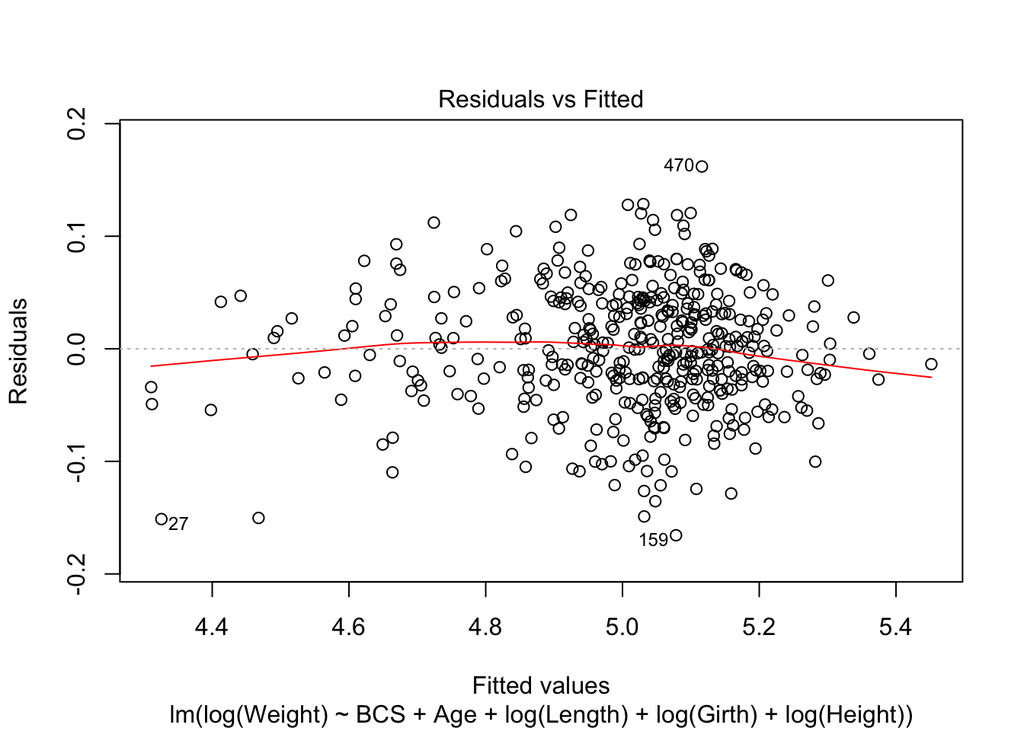

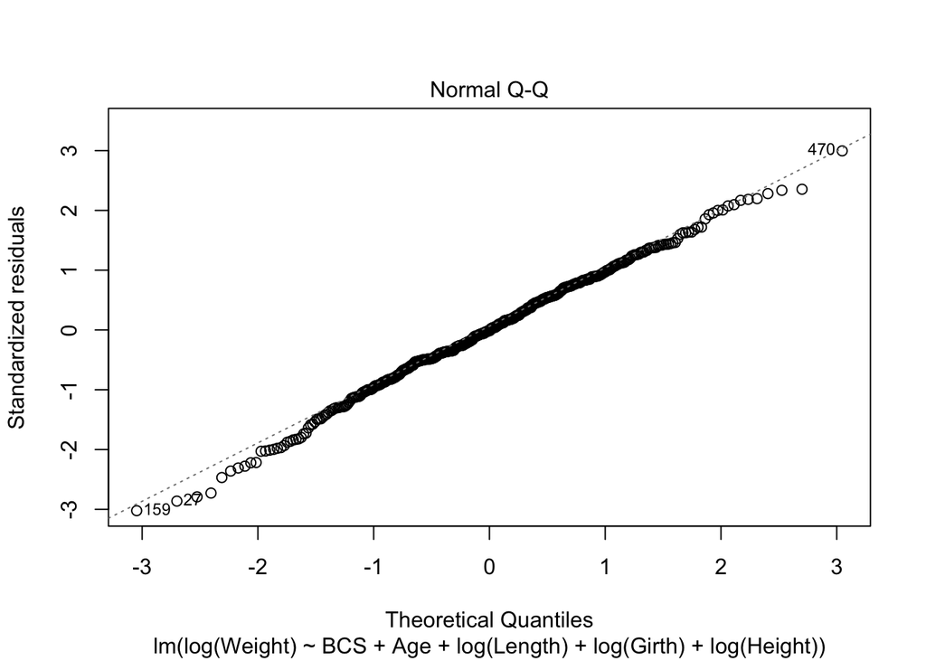

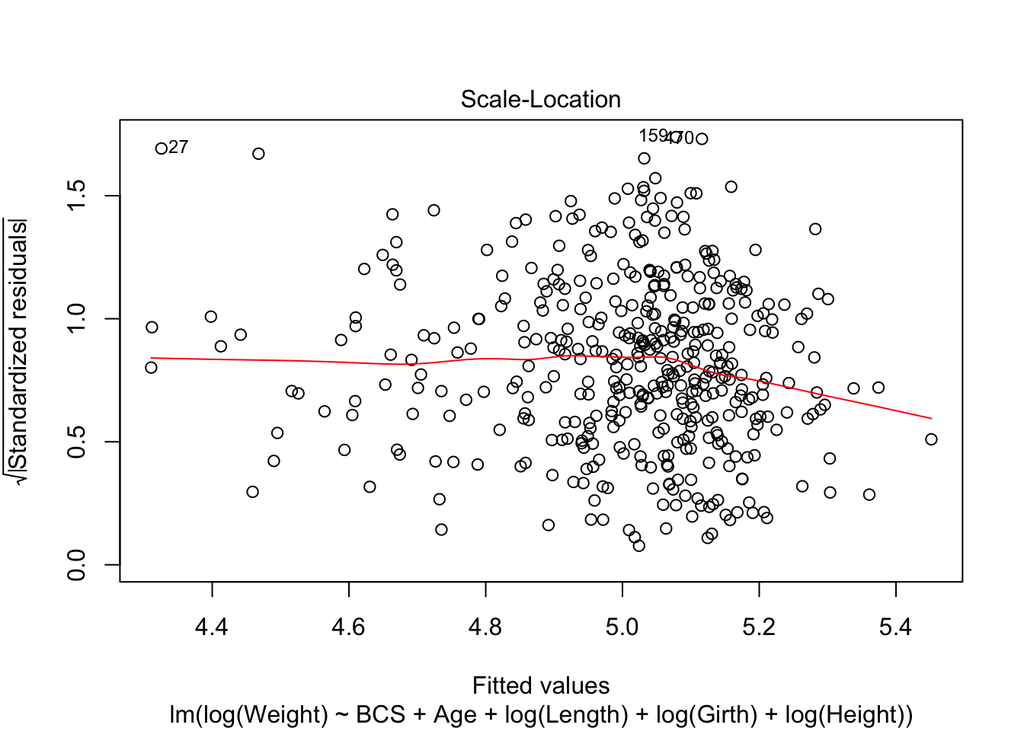

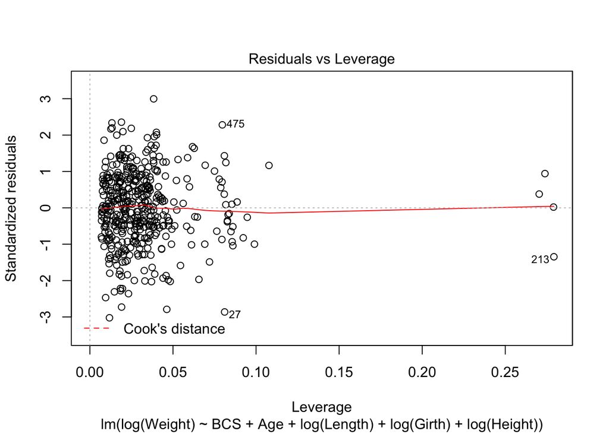

```r
plot(model)
```

- Everything looks good, except scale-location plot.

```r
bptest(model)
```

```
##
##  studentized Breusch-Pagan test
##
## data:  model
## BP = 22.425, df = 13, p-value = 0.04912
```

# Obtain results

```r
predictions = predict.lm(model, test, interval="confidence")
residuals = exp(predictions[,1]) - test$Weight
MSE = mean(residuals^2)
print(MSE)
```

```
## [1] 55.44327
```

```r
relative_error = exp(predictions[,1])/test$Weight
print(mean((relative_error-1)^2))
```

```
## [1] 0.002528694
```

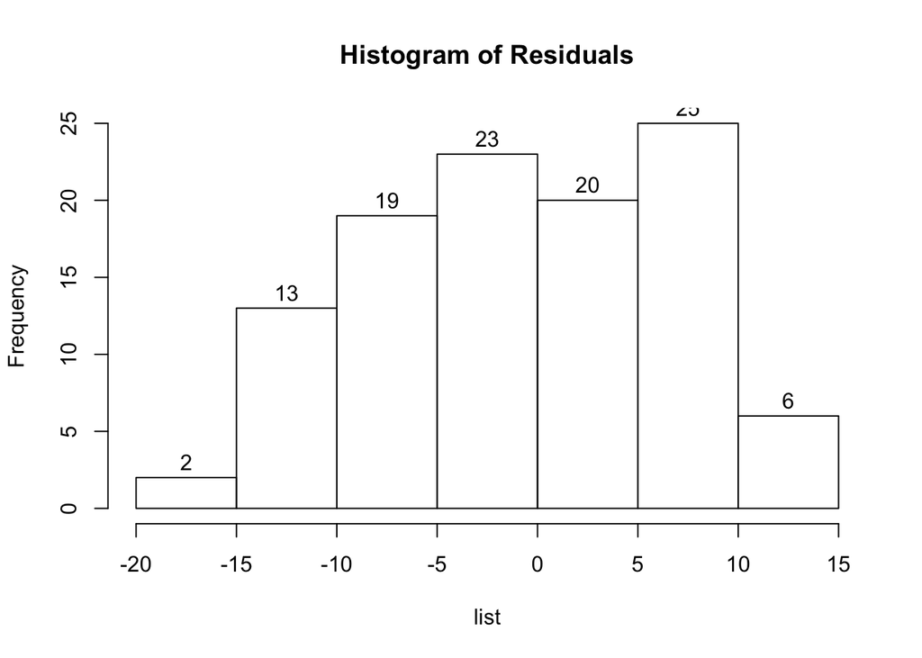

```r
plot_histogram(residuals, "Histogram of Residuals", FALSE)
```

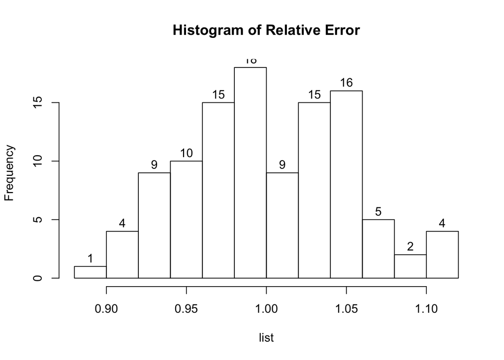

```r
plot_histogram(relative_error, "Histogram of Relative Error", FALSE)
```

# Sanity check that lm treats factors as hypothesized

```r
print(-7.40509+0.09277+0.61071*log(80)+1.46666*log(94)+0.54297*log(89))
```

```
## [1] 4.464491
```

```r
print(predictions[1,1])
```

```
## [1] 4.364334
```

# ToDo: Sensitivity analysis.